# 1. Introduction

[figure not shown]

Airbnb is an online marketplace for arranging or offering lodging, primarily homestays, or tourism experiences. Since 2008, guests and hosts have used Airbnb to expand on traveling possibilities. It renders an unique and personalized way of experiencing the world and socializing with new people. This dataset describes the listing activity and metrics in Boston, MA for 2019. This data file includes all needed information to find out more about hosts, geographical availability, necessary metrics to make predictions and draw conclusions. What can we learn about AirBnB rentals if we try to model their price?

The analysis could provide some insights on:

1. What features affect the price? By how much?
2. What are the popular description words in different price groups?
3. What is the effect of neighbour on price of the property?
4. Do superhosts actually charge high enough for their services?
5. How much do I have to pay for extra bedroom?

```python
import pandas as pd
import numpy as np
import matplotlib.pyplot as plt
import seaborn as sns
```

```python
%matplotlib inline
sns.set_style('darkgrid')
```

```python
# import data to dataframes
df = pd.read_csv('listings.csv')
```

# 2. EDA

```python
# Copy the dataframe for computation purpose
df_clean = df.copy()
```

```python
# First, let's drop some columns that are not useful for analysis
# To know the not usedul colums check the head of df and see whcih columns do you need.
cols = ['thumbnail_url', 'medium_url', 'picture_url', 'xl_picture_url', 'listing_url', 'host_url',
       'host_thumbnail_url', 'host_picture_url', 'country', 'country_code', 'neighbourhood',
       'smart_location', 'street', 'market', 'first_review', 'last_review', 'state', 'calendar_last_scraped',
       'calendar_updated', 'city', 'scrape_id', 'last_scraped', 'space', 'host_neighbourhood',
        'neighborhood_overview', 'host_listings_count', 'zipcode', 'is_location_exact', 'host_location',
       'host_total_listings_count']
df_clean.drop(cols, axis=1, inplace=True)
```

```python
# drop the colunms with more than half of the missing value
#imputing more than 50% of the values will result in garbage value this I avoid it
cols = df_clean.columns[df_clean.isnull().sum()/df_clean.shape[0] > 0.5]
df_clean.drop(cols, axis=1, inplace=True)
```

```python
# Next, let's fix some datatype errors, extract numbers and change to int type
# This is very important for doing calculation on the column
cols = ['host_response_rate', 'host_acceptance_rate', 'price', 'cleaning_fee', 'extra_people']
for col in cols:
    df_clean[col] = df_clean[col].str.extract(r'(\d+)')
    df_clean[col] = df_clean[col].astype('float128').astype('Int64')
df_clean[cols].dtypes
```

```
host_response_rate      Int64
host_acceptance_rate    Int64
price                   Int64
cleaning_fee            Int64
extra_people            Int64
dtype: object
```

```python
# Change datatype for host_since to date so that we can do date calculation
df_clean['host_since'] = pd.to_datetime(df_clean.host_since)
temp = pd.to_datetime('12/31/2019')
```

```python
df_clean['host_len'] = df_clean.host_since.apply(lambda x: pd.Timedelta(temp-x).days)
df_clean = df_clean.drop('host_since', axis=1)
```

```python
# extract the number of amenities
df_clean['n_amenities'] = df_clean['amenities'].apply(lambda x: len(x.replace('{', '').\
                        replace('{', '').replace('"', '').split(',')))
df_clean.drop('amenities', axis=1, inplace=True)
```

```python
df_num = df_clean.select_dtypes(include=['int', 'float'])
```

```python
# fill na for the columns
# As we have significant size data and it does not purposefully follow any distribution
# Thus mean is safest option to fill null
int_fillmean = lambda x: x.fillna(round(x.mean()))
df_num = df_num.apply(int_fillmean, axis=0)
df_num = df_num.drop(['id', 'host_id', 'latitude', 'longitude'], axis=1).astype(float)
```

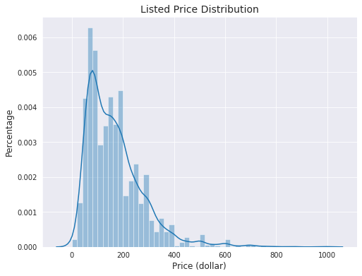

```python
# visualizae the price
plt.figure(figsize=(8, 6))
sns.distplot(df_num['price'], bins=50, kde=True)
plt.ylabel('Percentage', fontsize=12)
plt.xlabel('Price (dollar)', fontsize=12)
plt.title('Listed Price Distribution', fontsize=14);
```

```python
# we can see that some listed price are 1 dollar, which must be some data quality issue
df_num = df_num[df_num['price'] != 1]
# we will also exlude some outliers of the price > 1.5 IQR
df_num = df_num[df_num['price'] < 423]
```

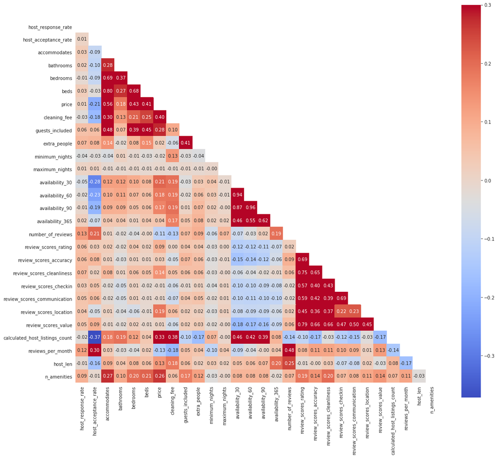

```python
# visualize the correlation matrix
corr = df_num.corr()
mask = np.zeros_like(corr)
mask[np.triu_indices_from(mask)] = True
with sns.axes_style("white"):
    f, ax = plt.subplots(figsize=(18, 16))
    ax = sns.heatmap(corr, mask=mask, vmax=.3, square=True, annot=True, fmt='.2f', cmap='coolwarm')
```

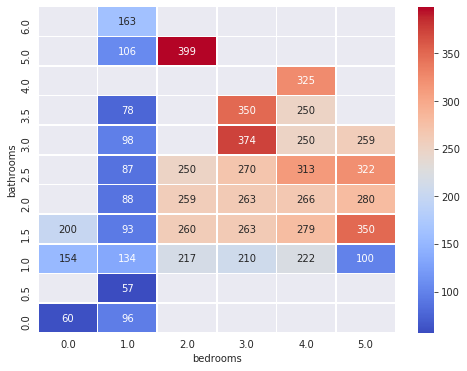

```python
# visualizae the price
plt.figure(figsize=(8, 6))
sns.heatmap(df_num.groupby(['bathrooms', 'bedrooms']).mean()['price'].reset_index()\
                .pivot('bathrooms', 'bedrooms', 'price').sort_index(ascending=False),
            cmap="coolwarm", fmt='.0f', annot=True, linewidths=0.5);
```

```python
# Next let's look at the categorical values
df_cat = df_clean.select_dtypes(include=['object'])
# we will drop few description lines for future analysis
df_cat = df_cat.drop(['name', 'summary', 'description', 'experiences_offered', 'host_about',
                      'host_verifications', 'host_name'], axis=1)
```

The interaction, house_rules, access can substantial a listing post. Maybe provide the information would attract more people and pontentially inrease the value of the listing. Since there are a lot of missing values in these columns, I would categorize them with t (with info) and f (without info).

```python
# find the not na rows with True
df_cat['with_inter'] = df_cat.interaction.notna().astype('object')
df_cat['with_access']= df_cat.access.notna().astype('object')
df_cat['with_rules'] = df_cat.house_rules.notna().astype('object')
df_cat['with_transit'] = df_cat.transit.notna().astype('object')
df_cat = df_cat.drop(['transit', 'access', 'interaction', 'house_rules'], axis=1)
```

```python
df_cat = pd.concat([df_cat, df_clean.price], axis=1)
df_cat = df_cat[df_cat['price'] != 1]
df_cat = df_cat[df_cat['price'] < 423]
```

```python
# get dummy values for categorical features
df_cat_dummies = pd.get_dummies(df_cat.iloc[:,:-1], dummy_na=False)
```

```python
# concatenate the model df
df_mod = pd.concat([df_num, df_cat_dummies], axis=1)
```

# 3. Popular Word and Word Cloud

## Popular word

```python
# We will first extract the dataframe for word analysis
df_word = df_clean.loc[:,['description', 'price']]
df_word = df_word[df_word.price!=1]
df_word = df_word[df_word.price<423]
df_word.sample(5)
```

|  | description | price |
| --- | --- | --- |
| 178 | We are steps to everything in the wonderful Bo... | 275 |
| 2323 | Less than a 5 minute walk to Newbury Street, H... | 200 |
| 3445 | Located in the heart of Allston, you can find ... | 58 |
| 2672 | The apartment is located on the lower level of... | 155 |
| 3476 | Amazing room with private half bath. Desk, dr... | 80 |

```python
# segment price into two groups
bin_edges = [0, 84, 145, 205, 417]
bin_name = ['25%', '50%', '75%', '100%']
df_word['price_bin'] = pd.cut(df_word['price'], bins=bin_edges, labels=bin_name)
```

```python
# get the post content for each price group
p_words = {};
for i in range(len(bin_name)):
    p_words[i] = ''
    df_i = df_word[df_word['price_bin'] == bin_name[i]]['description'].astype(str)
    for j in range(len(df_i)):
        words = df_i.iloc[j].split(' ')
        for word in words:
            p_words[i] += word+' '
```

```python
# Get the most popular 20 words for each price group
from collections import Counter
import string
counter = {}
occur = {}
stop_words = ['a', 'the', 'and', 'is', 'of', 'with', '', 'in', 'i', 'you', 'for', 'on', 'at', 'this', 'there',
              'that', 'to', 'from', 'have', 'has', 'we', 'your', 'my', 'are', 'be', 'or', 'will', 'our', 'it',
             'located', 'all', 'as']
for i in range(len(bin_name)):
    words = p_words[i].lower().translate(str.maketrans('', '', string.punctuation)).split(' ')
    counter[i] = Counter([word for word in words if word not in stop_words])
    occur[i] = counter[i].most_common(20)

df1 = pd.DataFrame.from_dict(occur[0]).rename(columns={0:'word', 1:'count'})
df2 = pd.DataFrame.from_dict(occur[1]).rename(columns={0:'word', 1:'count'})
df3 = pd.DataFrame.from_dict(occur[2]).rename(columns={0:'word', 1:'count'})
df4 = pd.DataFrame.from_dict(occur[3]).rename(columns={0:'word', 1:'count'})
```

```python
pd.DataFrame.from_dict(occur).rename(columns={0:'0%-25%', 1:'25%-50%', 2:'50%-75%', 3:'75%-100%'})
```

|  | 0%-25% | 25%-50% | 50%-75% | 75%-100% |
| --- | --- | --- | --- | --- |
| 0 | (room, 1389) | (boston, 1065) | (boston, 1145) | (boston, 1096) |
| 1 | (boston, 862) | (room, 952) | (apartment, 916) | (apartment, 975) |
| 2 | (kitchen, 673) | (apartment, 740) | (kitchen, 636) | (kitchen, 643) |
| 3 | (walk, 627) | (walk, 680) | (walk, 605) | (bedroom, 627) |
| 4 | (apartment, 536) | (kitchen, 621) | (bedroom, 600) | (room, 598) |
| 5 | (house, 504) | (bedroom, 591) | (room, 575) | (bed, 533) |
| 6 | (access, 451) | (private, 550) | (bed, 522) | (living, 508) |
| 7 | (line, 450) | (bed, 528) | (one, 489) | (•, 501) |
| 8 | (bed, 448) | (access, 480) | (street, 484) | (walk, 495) |
| 9 | (place, 441) | (bathroom, 437) | (living, 451) | (2, 422) |
| 10 | (bathroom, 437) | (downtown, 436) | (floor, 422) | (floor, 401) |
| 11 | (living, 436) | (living, 408) | (access, 408) | (one, 400) |
| 12 | (downtown, 418) | (street, 408) | (restaurants, 402) | (area, 393) |
| 13 | (home, 413) | (one, 408) | (end, 398) | (two, 392) |
| 14 | (bedroom, 407) | (2, 382) | (private, 372) | (private, 384) |
| 15 | (private, 403) | (area, 368) | (full, 355) | (restaurants, 381) |
| 16 | (bus, 377) | (restaurants, 366) | (2, 348) | (queen, 378) |
| 17 | (very, 375) | (line, 359) | (two, 337) | (full, 376) |
| 18 | (neighborhood, 374) | (great, 343) | (place, 335) | (street, 370) |
| 19 | (close, 373) | (place, 338) | (back, 332) | (unit, 366) |

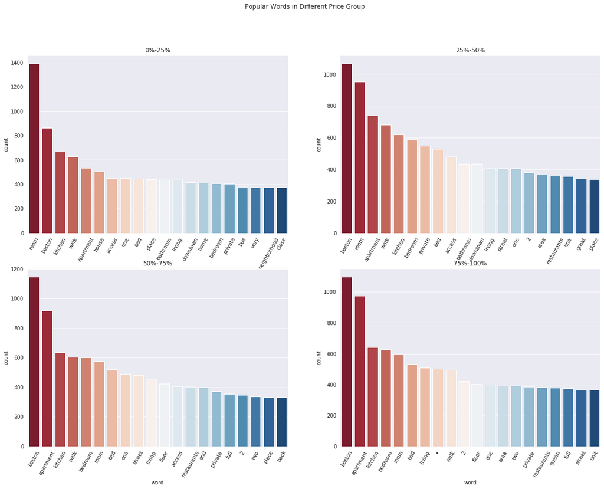

```python
# visualization
plt.figure(figsize=(20, 14))
plt.subplot(2, 2, 1)
ax1 = sns.barplot(data=df1, x='word', y='count', palette = 'RdBu')
plt.xticks(rotation=60)
plt.xlabel('')
plt.title('0%-25%', fontsize=12);

plt.subplot(2, 2, 2)
ax2 = sns.barplot(data=df2, x='word', y='count', palette = 'RdBu')
plt.xticks(rotation=60)
plt.xlabel('')
plt.title('25%-50%', fontsize=12)

plt.subplot(2, 2, 3)
ax2 = sns.barplot(data=df3, x='word', y='count', palette = 'RdBu')
plt.xticks(rotation=60)
plt.title('50%-75%', fontsize=12)

plt.subplot(2, 2, 4)
ax2 = sns.barplot(data=df4, x='word', y='count', palette = 'RdBu')
plt.xticks(rotation=60)
plt.title('75%-100%', fontsize=12)

plt.suptitle('Popular Words in Different Price Group');
```

## Word Cloud

```python
from wordcloud import WordCloud, STOPWORDS, ImageColorGenerator
stopwords = set(STOPWORDS)
stopwords.update(stop_words)
```

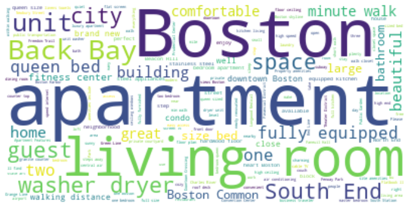

```python
# generate word cloud for high price group
wordcloud = WordCloud(background_color='white', max_words=1000, contour_width=3,contour_color='firebrick',
                      stopwords = stopwords)

wordcloud.generate(p_words[3])
plt.figure(figsize=(12,8))
plt.imshow(wordcloud, interpolation='bilinear')
plt.axis("off")
plt.show()
```

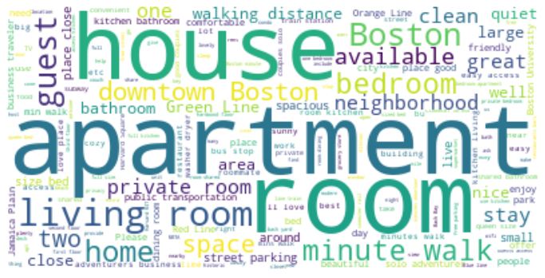

```python
# generate word cloud for low price group
wordcloud = WordCloud(background_color='white', max_words=1000, contour_width=3,contour_color='firebrick',
                      stopwords = stopwords)

wordcloud.generate(p_words[0])
plt.figure(figsize=(12,8))
plt.imshow(wordcloud, interpolation='bilinear')
plt.axis("off")
plt.show()
```

Looking at the word cloud, it is proved that the more expensive listings contains more information about the amenities, such as dryer and washer and fully-equipped, and they also emphasize the location (south end, back bay) more frequentyly.

# 4. Model Build

## Feature selection and Linear model

```python
from sklearn.model_selection import train_test_split
from sklearn.linear_model import LinearRegression
from sklearn.feature_selection import RFE
from sklearn.linear_model import RidgeCV, LassoCV, Ridge, Lasso
from sklearn import metrics
from sklearn.model_selection import cross_val_score
from sklearn.preprocessing import PolynomialFeatures
```

```python
# get the feature and label
X = df_mod.drop('price', axis=1)
y = df_mod['price']
```

```python
# There are two many features, let's select top 30 features with REF model
n = np.arange(5, 100, 5)
model = LinearRegression()
R2 = []
#Initializing RFE model
for num in n:
    rfe = RFE(model, num)
    #Transforming data using RFE
    X_rfe = rfe.fit_transform(X,y)
    #Fitting the data to model
    model.fit(X_rfe,y)
    # generate new feature matrix
    X_new = X.iloc[:,rfe.support_]
    # split training and testing model
    X_train, X_test, y_train, y_test = train_test_split(X_new, y, test_size=0.2, random_state=42)
    # fit the data
    lm = LinearRegression()
    lm.fit(X_train, y_train)
    pred = lm.predict(X_test)
    R2.append(metrics.r2_score(y_test, pred))
```

```python
ind = np.array(R2).argmax()
f_n = n[ind]
rfe = RFE(model, f_n)
X_rfe = rfe.fit_transform(X,y)
model.fit(X_rfe,y)
X_new = X.iloc[:,rfe.support_]
print('{} features are selected'.format(f_n))
```

```
95 features are selected
```

```python
# split training and testing model
X_train, X_test, y_train, y_test = train_test_split(X_new, y, test_size=0.2, random_state=42)
```

```python
# fit the data
lm = LinearRegression()
lm.fit(X_train, y_train)
pred = lm.predict(X_test)
```

```python
# evaluate
mse = metrics.mean_squared_error(y_test, pred)
r_square = metrics.r2_score(y_test, pred)

print('Mean absolute error is {}'.format(mse))
print('R^2 is {}'.format(r_square))
```

```
Mean absolute error is 2487.509790368887
R^2 is 0.6658298363431499
```

```python
# create a function to visualize the distribution of the prediction and the test
def DistributionPlot(RedFunction, BlueFunction, RedName, BlueName, Title):
    plt.figure(figsize=(10, 8))

    ax1 = sns.distplot(RedFunction, hist=False, color="r", label=RedName)
    ax2 = sns.distplot(BlueFunction, hist=False, color="b", label=BlueName, ax=ax1)
    plt.title(Title)
    plt.xlabel('Price (dollars)')
    plt.show()
    plt.close()
```

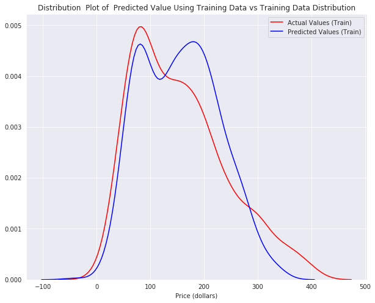

```python
# Visualize the results
DistributionPlot(y_test, pred, 'Actual Values (Train)', 'Predicted Values (Train)',
                 'Distribution  Plot of  Predicted Value Using Training Data vs Training Data Distribution')
```

## Cross-Validation

```python
Rcross = cross_val_score(lm, X_new, y, cv=10)
print("The mean of the folds are", Rcross.mean(), "and the standard deviation is" , Rcross.std())
```

```
The mean of the folds are 0.5060307082542469 and the standard deviation is 0.14522003374178155
```

## Ridge Regression

```python
# screen ridge model
RR_square = []
RR_train = []
alpha = [0.0001, 0.001, 0.1, 1, 10, 20]
for a in alpha:
    RigeModel = Ridge(alpha=a)
    RigeModel.fit(X_train, y_train)
    RR_square.append(RigeModel.score(X_test, y_test))
    RR_train.append(RigeModel.score(X_train, y_train))
```

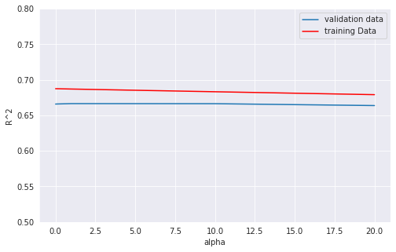

```python
# visualize
plt.figure(figsize=(8, 5))
plt.plot(alpha,RR_square, label='validation data')
plt.plot(alpha,RR_train, 'r', label='training Data')
plt.xlabel('alpha')
plt.ylabel('R^2')
plt.ylim(0.5, 0.8)
plt.legend();
```

```python
# Choose a ridge
RigeModel = Ridge(alpha=5)
RigeModel.fit(X_train, y_train)
rr_pred = RigeModel.predict(X_test)
print('r2 score is: {}'.format(RigeModel.score(X_test, y_test)))
```

```
r2 score is: 0.6669124461434093
```

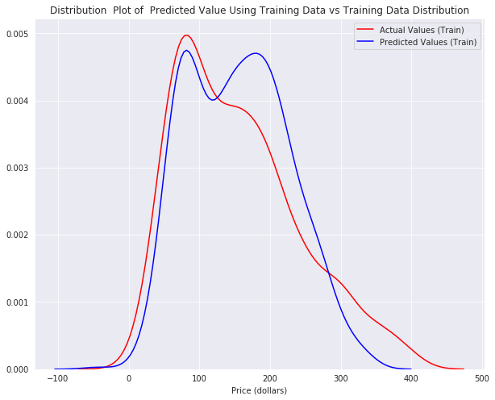

```python
# Visualize the results
DistributionPlot(y_test, rr_pred, 'Actual Values (Train)', 'Predicted Values (Train)',
                 'Distribution  Plot of  Predicted Value Using Training Data vs Training Data Distribution')
```

We can see that ridge only slightly improve the model...

# 5. Conclusion

```python
coef_df = pd.DataFrame(data=list(lm.coef_), index=X_new.columns).reset_index().rename(columns={'index': 'Var', 0: 'Coef'})
```

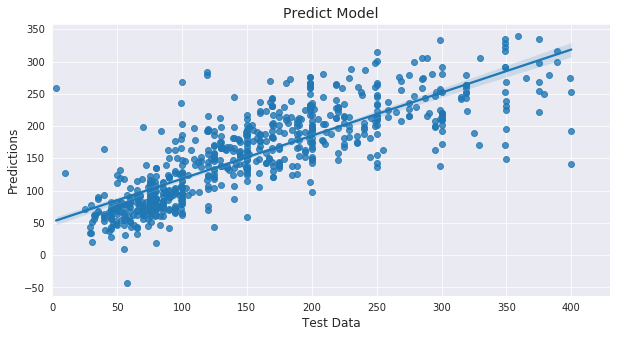

```python
# Predicted prive VS. actural price
plt.figure(figsize=(10,5))
sns.regplot(x=y_test, y=rr_pred, color=sns.color_palette()[0])
plt.xlim(0, 430)
plt.title('Predict Model', fontsize=14)
plt.xlabel('Test Data', fontsize=12)
plt.ylabel('Predictions', fontsize=12);
```

```python
# get the neighboorhood
neighborhoods = coef_df[coef_df.Var.str.contains('neighbourhood')].sort_values(by='Coef', ascending=False)
neighborhoods['Var'] = neighborhoods['Var'].apply(lambda x: x.split('_')[2])
```

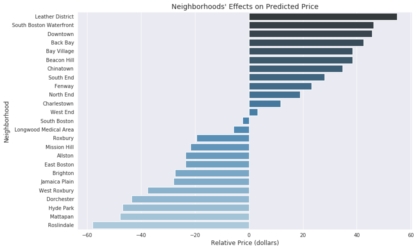

```python
# Visualize neighborhood effect on price
plt.figure(figsize=(12, 8))
sns.barplot(data=neighborhoods, x='Coef', y='Var', palette='Blues_d')
plt.xlabel('Relative Price (dollars)', fontsize=12)
plt.ylabel('Neighborhood', fontsize=12)
plt.title("Neighborhoods' Effects on Predicted Price", fontsize=14);
```

```python
# get the neighboorhood
property_type = coef_df[coef_df.Var.str.contains('property_type')].sort_values(by='Coef', ascending=False)
property_type['Var'] = property_type['Var'].apply(lambda x: x.split('_')[2])
```

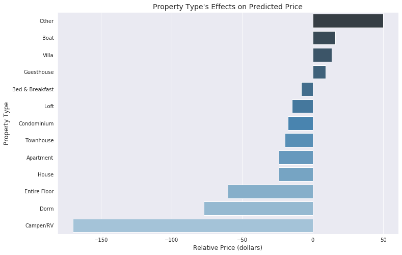

```python
# Visualize property_type effect on price
plt.figure(figsize=(12, 8))
sns.barplot(data=property_type, x='Coef', y='Var', palette='Blues_d')
plt.xlabel('Relative Price (dollars)', fontsize=12)
plt.ylabel('Property Type', fontsize=12)
plt.title("Property Type's Effects on Predicted Price", fontsize=14);
```

1. According to our model, every additional bedroom will cost extra 28.5 dollars, while each additional bathroom will cost extra 2.3 dollars. Each additional guests will cost 6 dollars more.
1. Neighbourhood areas strongly bias the price.
2. Superhosts' listings are 6 dollars more expensive on average.
3. Entire room on average will cost 76.6 more than a shared-room.
4. Type of property also effects the price, campers/RV are generally cheaper then boat or villa with shows positive corealation.